# HW2_UfukOzkan

```python
import numpy as np
import pandas as pd
import matplotlib.pyplot as plt
import seaborn as sns
```

## Import Data

```python
match_data = pd.read_csv("/Users/ufukozkan/Downloads/match_data")
```

## Data Summary

```python
print(match_data)
```

```
       fixture_id  halftime         current_time  half_start_datetime  \
0      19172016.0  1st-half  2024-08-09 18:11:36  2024-08-09 18:01:37
1      19172016.0  1st-half  2024-08-09 18:27:30  2024-08-09 18:01:37
2      19172016.0  1st-half  2024-08-09 18:28:25  2024-08-09 18:01:37
3      19172016.0  1st-half  2024-08-09 18:29:32  2024-08-09 18:01:37
4      19172016.0  1st-half  2024-08-09 18:30:37  2024-08-09 18:01:37
...           ...       ...                  ...                  ...
63939  19135376.0  2nd-half  2024-11-10 21:53:41  2024-11-10 21:06:59
63940  19135376.0  2nd-half  2024-11-10 21:54:41  2024-11-10 21:06:59
63941  19135376.0  2nd-half  2024-11-10 21:55:41  2024-11-10 21:06:59
63942  19135376.0  2nd-half  2024-11-10 21:56:41  2024-11-10 21:06:59
63943  19135376.0  2nd-half  2024-11-10 21:57:41  2024-11-10 21:06:59

      match_start_datetime  minute  second latest_bookmaker_update  suspended  \
0      2024-08-09 18:01:37       9      59     2024-08-09 18:11:28      False
```

[output cut: 64 more lines]

```python
match_data.head()
```

|  | fixture_id | halftime | current_time | half_start_datetime | match_start_datetime | minute | second | latest_bookmaker_update | suspended | stopped | ... | Throwins - home | Total Crosses - away | Total Crosses - home | Yellowcards - away | Yellowcards - home | Yellowred Cards - away | Yellowred Cards - home | current_state | final_score | result |
| --- | --- | --- | --- | --- | --- | --- | --- | --- | --- | --- | --- | --- | --- | --- | --- | --- | --- | --- | --- | --- | --- |
| 0 | 19172016.0 | 1st-half | 2024-08-09 18:11:36 | 2024-08-09 18:01:37 | 2024-08-09 18:01:37 | 9 | 59 | 2024-08-09 18:11:28 | False | False | ... | 1.0 | 0.0 | 3.0 | 0.0 | 0.0 | 0.0 | 0.0 | X | 2-1 | 1 |
| 1 | 19172016.0 | 1st-half | 2024-08-09 18:27:30 | 2024-08-09 18:01:37 | 2024-08-09 18:01:37 | 25 | 53 | 2024-08-09 18:27:24 | False | False | ... | 11.0 | 1.0 | 12.0 | 0.0 | 0.0 | 0.0 | 0.0 | X | 2-1 | 1 |
| 2 | 19172016.0 | 1st-half | 2024-08-09 18:28:25 | 2024-08-09 18:01:37 | 2024-08-09 18:01:37 | 26 | 48 | 2024-08-09 18:28:20 | False | False | ... | 11.0 | 1.0 | 13.0 | 0.0 | 0.0 | 0.0 | 0.0 | X | 2-1 | 1 |
| 3 | 19172016.0 | 1st-half | 2024-08-09 18:29:32 | 2024-08-09 18:01:37 | 2024-08-09 18:01:37 | 27 | 55 | 2024-08-09 18:29:28 | False | False | ... | 11.0 | 1.0 | 13.0 | 0.0 | 0.0 | 0.0 | 0.0 | X | 2-1 | 1 |
| 4 | 19172016.0 | 1st-half | 2024-08-09 18:30:37 | 2024-08-09 18:01:37 | 2024-08-09 18:01:37 | 29 | 0 | 2024-08-09 18:30:32 | True | False | ... | 11.0 | 1.0 | 14.0 | 0.0 | 0.0 | 0.0 | 0.0 | X | 2-1 | 1 |

5 rows × 106 columns

```python
match_data.describe()
```

|  | fixture_id | minute | second | 1 | 2 | X | Accurate Crosses - away | Accurate Crosses - home | Assists - away | Assists - home | ... | Tackles - away | Tackles - home | Throwins - away | Throwins - home | Total Crosses - away | Total Crosses - home | Yellowcards - away | Yellowcards - home | Yellowred Cards - away | Yellowred Cards - home |
| --- | --- | --- | --- | --- | --- | --- | --- | --- | --- | --- | --- | --- | --- | --- | --- | --- | --- | --- | --- | --- | --- |
| count | 6.394400e+04 | 63944.000000 | 63944.000000 | 63944.000000 | 63944.000000 | 63944.000000 | 60916.000000 | 60937.000000 | 36010.000000 | 36013.000000 | ... | 61984.000000 | 61995.000000 | 62811.000000 | 62818.000000 | 61729.000000 | 61740.000000 | 63864.000000 | 63875.000000 | 40700.000000 | 40707.000000 |
| mean | 1.914800e+07 | 25.476526 | 27.695421 | 18.510137 | 29.482377 | 8.698023 | 2.010276 | 2.631209 | 0.812746 | 0.901397 | ... | 8.411122 | 8.613533 | 8.751254 | 9.090722 | 7.766755 | 9.851749 | 0.911640 | 0.802630 | 0.011794 | 0.005503 |
| std | 1.345825e+04 | 14.496434 | 18.289720 | 64.166275 | 82.639170 | 12.092077 | 1.950212 | 2.292960 | 0.794087 | 0.826550 | ... | 5.695672 | 5.720836 | 5.957945 | 6.351125 | 6.054359 | 7.351268 | 1.166182 | 1.069864 | 0.117546 | 0.073977 |
| min | 1.913445e+07 | 0.000000 | 0.000000 | 1.000000 | 1.000000 | 1.000000 | 0.000000 | 0.000000 | 0.000000 | 0.000000 | ... | 0.000000 | 0.000000 | 0.000000 | 0.000000 | 0.000000 | 0.000000 | 0.000000 | 0.000000 | 0.000000 | 0.000000 |
| 25% | 1.913530e+07 | 13.000000 | 10.000000 | 1.330000 | 1.950000 | 3.000000 | 0.000000 | 1.000000 | 0.000000 | 0.000000 | ... | 4.000000 | 4.000000 | 4.000000 | 4.000000 | 3.000000 | 4.000000 | 0.000000 | 0.000000 | 0.000000 | 0.000000 |
| 50% | 1.913974e+07 | 25.000000 | 27.000000 | 2.500000 | 4.000000 | 3.750000 | 2.000000 | 2.000000 | 1.000000 | 1.000000 | ... | 8.000000 | 8.000000 | 8.000000 | 8.000000 | 7.000000 | 9.000000 | 1.000000 | 0.000000 | 0.000000 | 0.000000 |
| 75% | 1.915513e+07 | 38.000000 | 44.000000 | 5.500000 | 13.000000 | 7.500000 | 3.000000 | 4.000000 | 1.000000 | 1.000000 | ... | 12.000000 | 13.000000 | 13.000000 | 13.000000 | 11.000000 | 14.000000 | 1.000000 | 1.000000 | 0.000000 | 0.000000 |
| max | 1.917212e+07 | 80.000000 | 59.000000 | 501.000000 | 501.000000 | 51.000000 | 12.000000 | 14.000000 | 5.000000 | 6.000000 | ... | 33.000000 | 33.000000 | 34.000000 | 45.000000 | 45.000000 | 46.000000 | 9.000000 | 7.000000 | 2.000000 | 1.000000 |

8 rows × 94 columns

```python
[x for x in match_data.columns]
```

```
['fixture_id',
 'halftime',
 'current_time',
 'half_start_datetime',
 'match_start_datetime',
 'minute',
 'second',
 'latest_bookmaker_update',
 'suspended',
 'stopped',
 '1',
 '2',
 'X',
 'name',
 'ticking',
 'Accurate Crosses - away',
 'Accurate Crosses - home',
 'Assists - away',
 'Assists - home',
 'Attacks - away',
 'Attacks - home',
 'Ball Possession % - away',
 'Ball Possession % - home',
 'Ball Safe - away',
 'Ball Safe - home',
 'Challenges - away',
 'Challenges - home',
 'Corners - away',
 'Corners - home',
 'Counter Attacks - away',
 'Counter Attacks - home',
 'Dangerous Attacks - away',
 'Dangerous Attacks - home',
 'Dribble Attempts - away',
 'Dribble Attempts - home',
 'Fouls - away',
 'Fouls - home',
 'Free Kicks - away',
 'Free Kicks - home',
 'Goal Attempts - away',
```

[output cut: 51 more lines]

```
 'Successful Passes Percentage - away',
 'Successful Passes Percentage - home',
 'Tackles - away',
 'Tackles - home',
 'Throwins - away',
 'Throwins - home',
 'Total Crosses - away',
 'Total Crosses - home',
 'Yellowcards - away',
 'Yellowcards - home',
 'Yellowred Cards - away',
 'Yellowred Cards - home',
 'current_state',
 'final_score',
 'result']
```

# Null Values

```python
match_data.isna().sum().sort_values()
```

```
fixture_id                    0
Shots Total - home            0
Shots Total - away            0
Score Change - home           0
Score Change - away           0
                          ...
Counter Attacks - away    41211
Injuries - home           46316
Injuries - away           46318
Free Kicks - away         58465
Free Kicks - home         58465
Length: 106, dtype: int64
```

## Number of Minutes Available in Matches

```python
match_data.groupby("fixture_id")["minute"].size().sort_values()
```

```
fixture_id
19172016.0     39
19172012.0     47
19172089.0     52
19172085.0     54
19172014.0     70
             ...
19135321.0    109
19134483.0    109
19172104.0    110
19139727.0    113
19139657.0    129
Name: minute, Length: 648, dtype: int64
```

## Odd Changes By Goals

```python
matches_with_home_goals = sorted(list(set(match_data[match_data["Score Change - home"] == 1]["fixture_id"])))
```

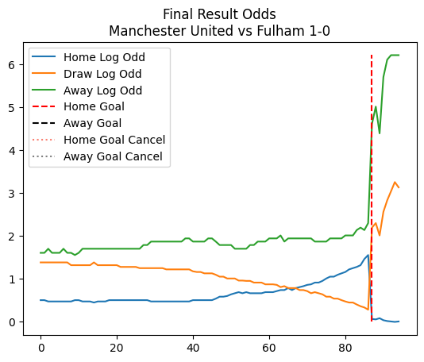

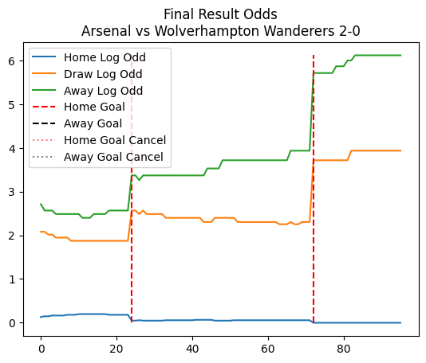

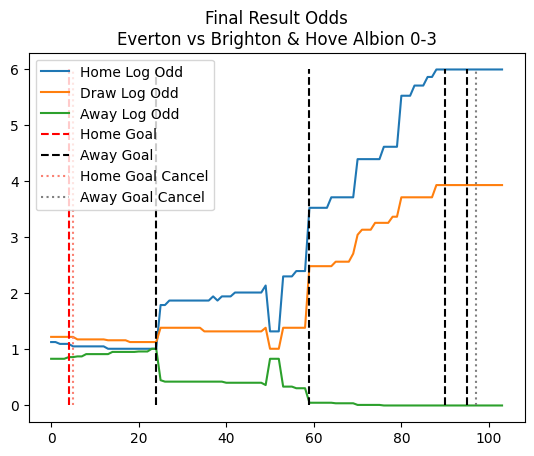

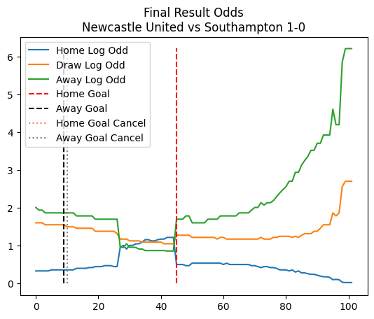

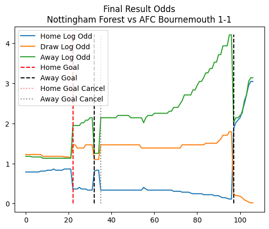

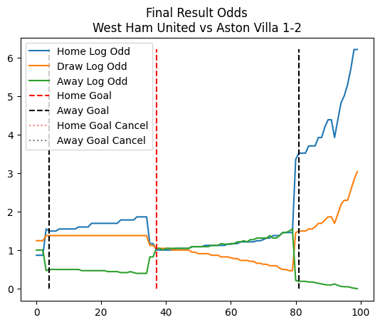

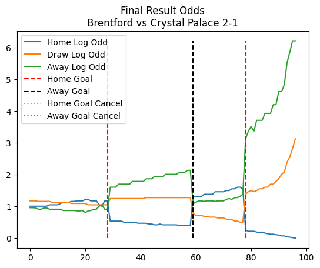

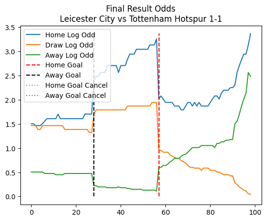

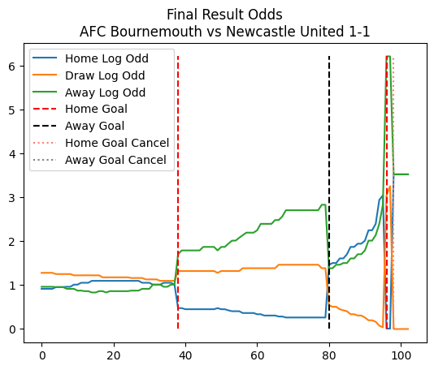

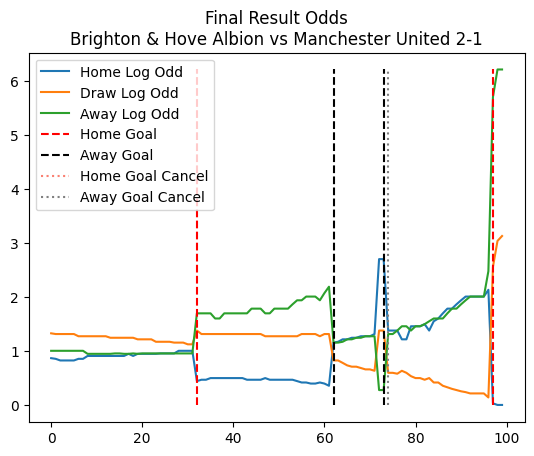

```python
for selected_match in matches_with_home_goals[:10]: # show some of the games
    selected_match_data = match_data[match_data["fixture_id"] == selected_match].reset_index(drop=True)

    plt.plot(np.log(selected_match_data["1"]))
    plt.plot(np.log(selected_match_data["X"]))
    plt.plot(np.log(selected_match_data["2"]))

    plt.title("Final Result Odds\n" + selected_match_data["name"][0] + " " + selected_match_data["final_score"][0])

    plt.vlines(np.where(selected_match_data["Score Change - home"] == 1),0,np.log(selected_match_data[["1","2","X"]].max().max()),color="red",linestyles="dashed")
    plt.vlines(np.where(selected_match_data["Score Change - away"] == 1),0,np.log(selected_match_data[["1","2","X"]].max().max()),color="black",linestyles="dashed")
    plt.vlines(np.where(selected_match_data["Score Change - home"] == -1),0,np.log(selected_match_data[["1","2","X"]].max().max()),color="salmon",linestyles="dotted")
    plt.vlines(np.where(selected_match_data["Score Change - away"] == -1),0,np.log(selected_match_data[["1","2","X"]].max().max()),color="gray",linestyles="dotted")

    plt.legend(["Home Log Odd","Draw Log Odd","Away Log Odd","Home Goal","Away Goal","Home Goal Cancel","Away Goal Cancel"])
    plt.show()
```

```python
filtered_match_data = match_data[(match_data['suspended'] == False) & (match_data['stopped'] == False)]

original_row_count = len(match_data)
filtered_row_count = len(filtered_match_data)

original_row_count, filtered_row_count
```

```
(63944, 56127)
```

```python
filtered_match_data['P_home_win'] = 1 / filtered_match_data['1']
filtered_match_data['P_draw'] = 1 / filtered_match_data['X']
filtered_match_data['P_away_win'] = 1 / filtered_match_data['2']

filtered_match_data[['P_home_win', 'P_draw', 'P_away_win']].head()
```

|  | P_home_win | P_draw | P_away_win |
| --- | --- | --- | --- |
| 0 | 0.819672 | 0.153846 | 0.100000 |
| 1 | 0.833333 | 0.166667 | 0.076923 |
| 2 | 0.833333 | 0.166667 | 0.076923 |
| 3 | 0.833333 | 0.166667 | 0.076923 |
| 8 | 0.833333 | 0.166667 | 0.066667 |

```python
filtered_match_data = filtered_match_data.copy()

denominator = (
    filtered_match_data['P_home_win'] +
    filtered_match_data['P_draw'] +
    filtered_match_data['P_away_win']
)

filtered_match_data = filtered_match_data[denominator != 0]

# Normalizasyon işlemleri
filtered_match_data.loc[:, 'P_home_win_norm'] = filtered_match_data['P_home_win'] / denominator
filtered_match_data.loc[:, 'P_draw_norm'] = filtered_match_data['P_draw'] / denominator
filtered_match_data.loc[:, 'P_away_win_norm'] = filtered_match_data['P_away_win'] / denominator

print(filtered_match_data[['P_home_win_norm', 'P_draw_norm', 'P_away_win_norm']].head())
```

```
   P_home_win_norm  P_draw_norm  P_away_win_norm
0         0.763538     0.143310         0.093152
1         0.773810     0.154762         0.071429
2         0.773810     0.154762         0.071429
3         0.773810     0.154762         0.071429
8         0.781250     0.156250         0.062500
```

```python
filtered_match_data['P_home_win'] = 1 / filtered_match_data['1']
filtered_match_data['P_draw'] = 1 / filtered_match_data['X']
filtered_match_data['P_away_win'] = 1 / filtered_match_data['2']

filtered_match_data['P_diff'] = filtered_match_data['P_home_win'] - filtered_match_data['P_away_win']
```

```python
print(filtered_match_data[['P_diff', 'P_draw']].isnull().sum())
filtered_match_data = filtered_match_data.dropna(subset=['P_diff', 'P_draw'])
```

```
P_diff    0
P_draw    0
dtype: int64
```

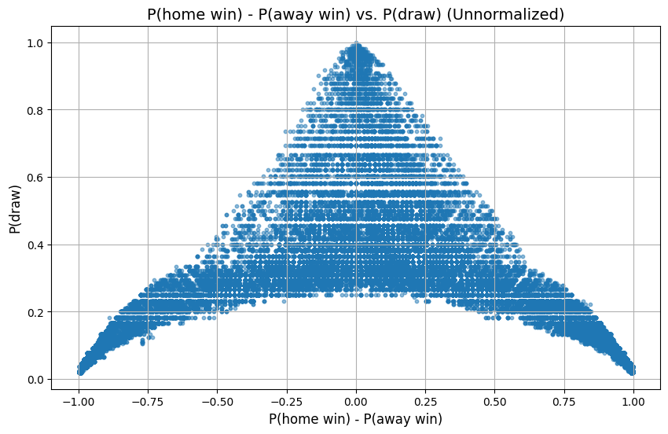

```python
import matplotlib.pyplot as plt

# Calculate P(home win) - P(away win) for the x-axis
filtered_match_data.loc['P_diff'] = filtered_match_data['P_home_win'] - filtered_match_data['P_away_win']

# Plot P_diff vs. P_draw
plt.figure(figsize=(10, 6))
plt.scatter(filtered_match_data['P_diff'], filtered_match_data['P_draw'], alpha=0.5, s=10)
plt.title('P(home win) - P(away win) vs. P(draw) (Unnormalized)', fontsize=14)
plt.xlabel('P(home win) - P(away win)', fontsize=12)
plt.ylabel('P(draw)', fontsize=12)
plt.grid(True)
plt.show()
```

```
      P_diff_bin  Games_in_bin  Draws_in_bin  Draw_probability
0   (-1.0, -0.9]        3334.0         215.0          0.064487
1   (-0.9, -0.8]        1923.0         309.0          0.160686
2   (-0.8, -0.7]        1711.0         303.0          0.177089
3   (-0.7, -0.6]        1478.0         342.0          0.231394
4   (-0.6, -0.5]        1392.0         403.0          0.289511
5   (-0.5, -0.4]        1478.0         494.0          0.334235
6   (-0.4, -0.3]        1699.0         499.0          0.293702
7   (-0.3, -0.2]        2373.0         824.0          0.347240
8   (-0.2, -0.1]        3085.0        1151.0          0.373096
9    (-0.1, 0.0]        3848.0        1528.0          0.397089
10    (0.0, 0.1]        4548.0        2172.0          0.477573
11    (0.1, 0.2]        4413.0        2023.0          0.458418
12    (0.2, 0.3]        3127.0        1250.0          0.399744
13    (0.3, 0.4]        2829.0         973.0          0.343938
14    (0.4, 0.5]        2558.0         743.0          0.290461
15    (0.5, 0.6]        1954.0         420.0          0.214944
16    (0.6, 0.7]        2582.0         431.0          0.166925
17    (0.7, 0.8]        2755.0         547.0          0.198548
18    (0.8, 0.9]        3265.0         458.0          0.140276
19    (0.9, 1.0]        5775.0         306.0          0.052987
```

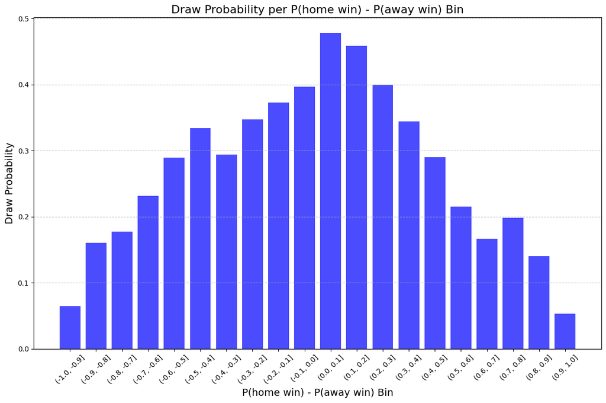

```python
filtered_data = match_data[(match_data['suspended'] == False) & (match_data['stopped'] == False)]
filtered_data['P_home_win'] = 1 / filtered_data['1']
filtered_data['P_draw'] = 1 / filtered_data['X']
filtered_data['P_away_win'] = 1 / filtered_data['2']
filtered_data['P_diff'] = filtered_data['P_home_win'] - filtered_data['P_away_win']
bins = np.linspace(-1, 1, 21)  # Create 20 bins between -1 and 1
filtered_data['P_diff_bin'] = pd.cut(filtered_data['P_diff'], bins)
bin_stats = filtered_data.groupby('P_diff_bin').apply(
    lambda group: pd.Series({
        'Games_in_bin': len(group),
        'Draws_in_bin': (group['result'] == 'X').sum(),
        'Draw_probability': (group['result'] == 'X').mean()
    })
)

# Display the bin statistics


bin_stats.reset_index(inplace=True)
print(bin_stats)
plt.figure(figsize=(12, 8))
plt.bar(bin_stats['P_diff_bin'].astype(str), bin_stats['Draw_probability'], color='blue', alpha=0.7)
plt.title('Draw Probability per P(home win) - P(away win) Bin', fontsize=16)
plt.xlabel('P(home win) - P(away win) Bin', fontsize=14)
plt.ylabel('Draw Probability', fontsize=14)
plt.xticks(rotation=45, fontsize=10)
plt.grid(axis='y', linestyle='--', alpha=0.7)
plt.tight_layout()
plt.show()
```

Results

Example statistics: Bin (-0.1, 0.0): Draw_probability = 0.397089. Bin (0.0, 0.1): Draw_probability = 0.477573 (highest probability). Bin (0.9, 1.0): Draw_probability = 0.052987 (lowest probability). Visualization: The bar chart provided a clear distribution of draw probabilities across the bins. The peak occurred near P_diff = 0, aligning with the statistical summary. Data Reduction: After filtering and preprocessing, 56,127 rows remained for analysis, reducing data size by approximately 12%. Figures:

Figure 1: Table summarizing bin statistics (P_diff_bin, Games_in_bin, Draws_in_bin, Draw_probability).

Figure 2: Bar chart visualizing the Draw_probability across P_diff bins.

Conclusions:

The analysis successfully demonstrated the relationship between balanced probabilities (P_diff) and the likelihood of a draw in football matches. Matches with more balanced odds between teams are more likely to result in a draw, as indicated by the higher probabilities around P_diff = 0.

TASK2

```python
late_goal_matches = match_data[
    (match_data['minute'] > 90) &
    (
        ((match_data['current_state'] == 'home_win') & (match_data['result'] == 'draw')) |  # The team ahead draws
        ((match_data['current_state'] == 'away_win') & (match_data['result'] == 'draw')) |  # The team ahead draws
        ((match_data['current_state'] == 'draw') & (match_data['result'] == 'home_win')) |  # The home team wins from a draw
        ((match_data['current_state'] == 'draw') & (match_data['result'] == 'away_win'))    # The away team wins from a draw
    )
]['fixture_id'].unique()

early_red_card_matches = match_data[
    (match_data['minute'] <= 15) &
    ((match_data['Yellowred Cards - home'] > 0) | (match_data['Yellowred Cards - away'] > 0))
]['fixture_id'].unique()

matches_to_remove = set(late_goal_matches).union(set(early_red_card_matches))
filtered_cleaned_data = match_data[~match_data['fixture_id'].isin(matches_to_remove)]

late_goal_count = len(late_goal_matches)
early_red_card_count = len(early_red_card_matches)
total_removed_matches = len(matches_to_remove)

print(f"90. dakikadan sonra sonucu değiştiren maç sayisi: {late_goal_count}")
print(f"İlk 15 dakikada kirmizi kart görülen maç sayisi: {early_red_card_count}")
print(f"Toplam çikarilan maç sayisi: {total_removed_matches}")
```

```
90. dakikadan sonra sonucu değiştiren maç sayisi: 0
İlk 15 dakikada kirmizi kart görülen maç sayisi: 6
Toplam çikarilan maç sayisi: 6
```

```python
# P_diff calculation
filtered_cleaned_data.loc[:,'P_home_win'] = 1 / filtered_cleaned_data['1']
filtered_cleaned_data.loc[:,'P_draw'] = 1 / filtered_cleaned_data['X']
filtered_cleaned_data.loc[:,'P_away_win'] = 1 / filtered_cleaned_data['2']

filtered_cleaned_data.loc[:,'P_diff'] = filtered_cleaned_data['P_home_win'] - filtered_cleaned_data['P_away_win']

bins = np.linspace(-1, 1, 21)  # 20 eşit aralık
filtered_cleaned_data.loc[:,'P_diff_bin'] = pd.cut(filtered_cleaned_data['P_diff'], bins)
```

```python
# Analysis for each bins
bin_stats_cleaned = filtered_cleaned_data.groupby('P_diff_bin').apply(
    lambda group: pd.Series({
        'Games_in_bin': len(group),
        'Draws_in_bin': (group['result'] == 'X').sum(),
        'Draw_probability': (group['result'] == 'X').mean()
    })
)

# Adding bookmaker predictions
filtered_cleaned_data['Implied_draw_prob'] = filtered_cleaned_data['P_draw'] / (
    filtered_cleaned_data['P_home_win'] + filtered_cleaned_data['P_draw'] + filtered_cleaned_data['P_away_win']
)

bin_stats_cleaned['Avg_implied_draw_prob'] = filtered_cleaned_data.groupby('P_diff_bin')['Implied_draw_prob'].mean()
bin_stats_cleaned['Difference'] = bin_stats_cleaned['Draw_probability'] - bin_stats_cleaned['Avg_implied_draw_prob']
```

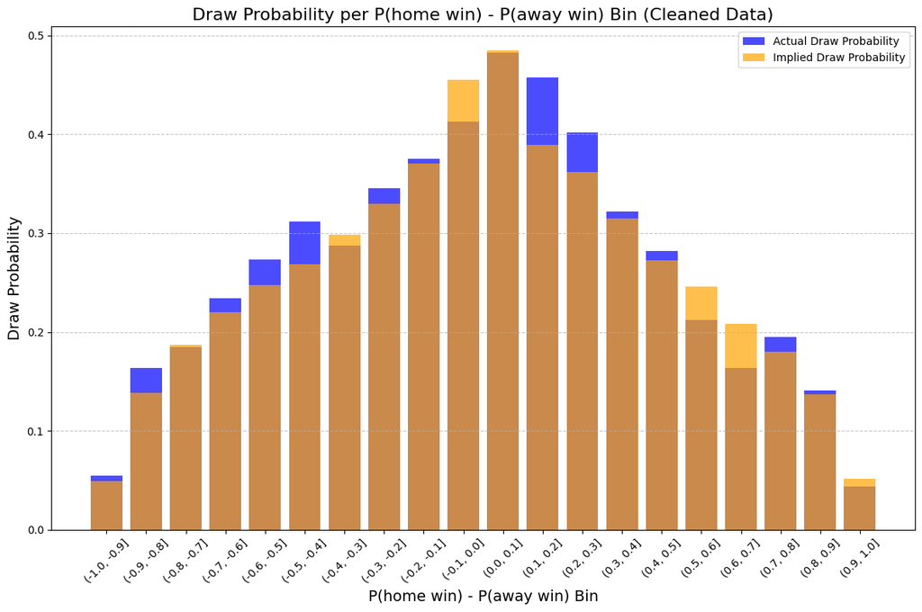

```python
# "Draw Probability" Visualization
plt.figure(figsize=(12, 8))
plt.bar(bin_stats_cleaned.index.astype(str), bin_stats_cleaned['Draw_probability'], color='blue', alpha=0.7, label="Actual Draw Probability")
plt.bar(bin_stats_cleaned.index.astype(str), bin_stats_cleaned['Avg_implied_draw_prob'], color='orange', alpha=0.7, label="Implied Draw Probability")
plt.title('Draw Probability per P(home win) - P(away win) Bin (Cleaned Data)', fontsize=16)
plt.xlabel('P(home win) - P(away win) Bin', fontsize=14)
plt.ylabel('Draw Probability', fontsize=14)
plt.xticks(rotation=45, fontsize=10)
plt.legend()
plt.grid(axis='y', linestyle='--', alpha=0.7)
plt.tight_layout()
plt.show()
```

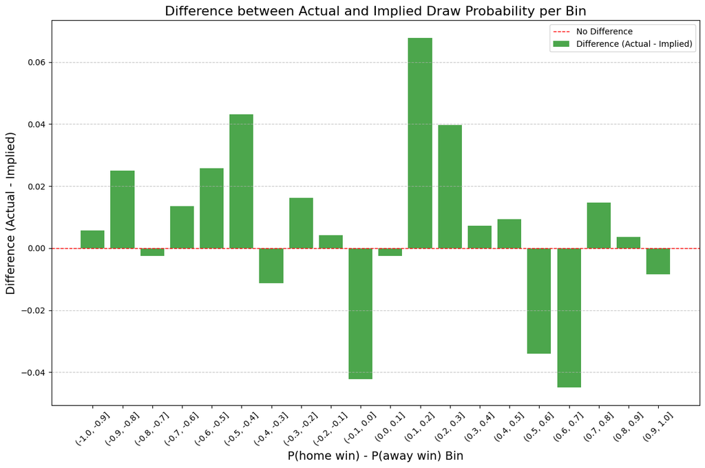

```python
plt.figure(figsize=(12, 8))
plt.bar(bin_stats_cleaned.index.astype(str), bin_stats_cleaned['Difference'], color='green', alpha=0.7, label="Difference (Actual - Implied)")
plt.axhline(0, color='red', linestyle='--', linewidth=1, label="No Difference")
plt.title('Difference between Actual and Implied Draw Probability per Bin', fontsize=16)
plt.xlabel('P(home win) - P(away win) Bin', fontsize=14)
plt.ylabel('Difference (Actual - Implied)', fontsize=14)
plt.xticks(rotation=45, fontsize=10)
plt.legend()
plt.grid(axis='y', linestyle='--', alpha=0.7)
plt.tight_layout()
plt.show()
```

```python
# Önceki Task 1 sonuçları ile temizlenmiş sonuçları karşılaştırma
comparison = pd.DataFrame({
    'Draw Probability (Original)': bin_stats['Draw_probability'],
    'Draw Probability (Cleaned)': bin_stats_cleaned['Draw_probability'],
    'Difference': bin_stats_cleaned['Draw_probability'] - bin_stats['Draw_probability']
})
print(comparison)
```

```
              Draw Probability (Original)  Draw Probability (Cleaned)  \
0                                0.064487                    0.412740
1                                0.160686                    0.043525
2                                0.177089                         NaN
3                                0.231394                         NaN
4                                0.289511                         NaN
5                                0.334235                         NaN
6                                0.293702                         NaN
7                                0.347240                         NaN
8                                0.373096                         NaN
9                                0.397089                         NaN
10                               0.477573                         NaN
11                               0.458418                         NaN
12                               0.399744                         NaN
13                               0.343938                         NaN
14                               0.290461                         NaN
15                               0.214944                         NaN
16                               0.166925                         NaN
17                               0.198548                         NaN
18                               0.140276                         NaN
19                               0.052987                         NaN
(-1.0, -0.9]                          NaN                    0.054757
(-0.9, -0.8]                          NaN                    0.163618
(-0.8, -0.7]                          NaN                    0.184728
(-0.7, -0.6]                          NaN                    0.233933
(-0.6, -0.5]                          NaN                    0.273548
(-0.5, -0.4]                          NaN                    0.311680
(-0.4, -0.3]                          NaN                    0.287162
(-0.3, -0.2]                          NaN                    0.345714
(-0.2, -0.1]                          NaN                    0.374883
(-0.1, 0.0]                           NaN                    0.412740
(0.0, 0.1]                            NaN                    0.482200
(0.1, 0.2]                            NaN                    0.457230
(0.2, 0.3]                            NaN                    0.401589
(0.3, 0.4]                            NaN                    0.321835
(0.4, 0.5]                            NaN                    0.281637
(0.5, 0.6]                            NaN                    0.211835
(0.6, 0.7]                            NaN                    0.163610
(0.7, 0.8]                            NaN                    0.195130
(0.8, 0.9]                            NaN                    0.140706
```

[output cut: 28 more lines]

```
(-0.5, -0.4]         NaN
(-0.4, -0.3]         NaN
(-0.3, -0.2]         NaN
(-0.2, -0.1]         NaN
(-0.1, 0.0]          NaN
(0.0, 0.1]           NaN
(0.1, 0.2]           NaN
(0.2, 0.3]           NaN
(0.3, 0.4]           NaN
(0.4, 0.5]           NaN
(0.5, 0.6]           NaN
(0.6, 0.7]           NaN
(0.7, 0.8]           NaN
(0.8, 0.9]           NaN
(0.9, 1.0]           NaN
```

```python
filtered_cleaned_data['P_diff_bin_dynamic'] = pd.qcut(filtered_cleaned_data['P_diff'], q=20)
dynamic_bin_stats = filtered_cleaned_data.groupby('P_diff_bin_dynamic').apply(
    lambda group: pd.Series({
        'Games_in_bin': len(group),
        'Draws_in_bin': (group['result'] == 'X').sum(),
        'Draw_probability': (group['result'] == 'X').mean()
    })
)
print(dynamic_bin_stats)
```

```
                    Games_in_bin  Draws_in_bin  Draw_probability
P_diff_bin_dynamic
(-0.999, -0.965]          3184.0          66.0          0.020729
(-0.965, -0.845]          3170.0         398.0          0.125552
(-0.845, -0.662]          3156.0         624.0          0.197719
(-0.662, -0.455]          3190.0         830.0          0.260188
(-0.455, -0.276]          3295.0        1022.0          0.310167
(-0.276, -0.16]           3029.0        1035.0          0.341697
(-0.16, -0.0667]          3152.0        1172.0          0.371827
(-0.0667, 0.00502]        3169.0        1416.0          0.446829
(0.00502, 0.0682]         3204.0        1588.0          0.495630
(0.0682, 0.127]           3121.0        1375.0          0.440564
(0.127, 0.2]              3186.0        1502.0          0.471438
(0.2, 0.295]              3152.0        1269.0          0.402602
(0.295, 0.402]            3298.0        1064.0          0.322620
(0.402, 0.526]            3033.0         838.0          0.276294
(0.526, 0.664]            3214.0         603.0          0.187617
(0.664, 0.775]            3133.0         564.0          0.180019
(0.775, 0.871]            3181.0         505.0          0.158755
(0.871, 0.942]            3163.0         231.0          0.073032
(0.942, 0.988]            3382.0         211.0          0.062389
(0.988, 0.998]            2927.0          35.0          0.011958
```

TASK3

```python
from sklearn.model_selection import train_test_split
from sklearn.preprocessing import LabelEncoder


X = filtered_cleaned_data.drop(columns=['result', 'fixture_id', 'current_time', 'halftime', 'match_start_datetime', 'half_start_datetime'])
y = filtered_cleaned_data['result']


label_encoder = LabelEncoder()
y = label_encoder.fit_transform(y)
X_train, X_test, y_train, y_test = train_test_split(X, y, test_size=0.2, random_state=42)
```

```python
y = pd.Series(y, name="result")
combined = pd.concat([X_cleaned, y], axis=1).dropna()

X_cleaned = combined.iloc[:, :-1]
y = combined.iloc[:, -1]
from sklearn.model_selection import train_test_split

X_train, X_test, y_train, y_test = train_test_split(X_cleaned, y, test_size=0.2, random_state=42)
```

```python
combined = pd.concat([X_cleaned, y], axis=1).dropna()
X_cleaned = combined.iloc[:, :-1]
y = combined.iloc[:, -1]


X_train, X_test, y_train, y_test = train_test_split(X_cleaned, y, test_size=0.2, random_state=42)
```

[figure not shown]

```python
from sklearn.model_selection import train_test_split
from sklearn.preprocessing import LabelEncoder
from sklearn.tree import DecisionTreeClassifier
import matplotlib.pyplot as plt
from sklearn import tree


y = match_data['result']


label_encoder = LabelEncoder()
y = label_encoder.fit_transform(y)

features = ['minute', 'second', 'ticking', 'P_home_win', 'P_draw', 'P_away_win', 'P_diff']
X_cleaned = X[features]


X_cleaned = X_cleaned.fillna(0)

decision_tree = DecisionTreeClassifier(max_depth=5, random_state=42)
decision_tree.fit(X_train, y_train)

plt.figure(figsize=(20, 10))
tree.plot_tree(decision_tree, feature_names=X_cleaned.columns, class_names=label_encoder.classes_, filled=True)
plt.title("Decision Tree for Match Results")
plt.show()
```

```python
from sklearn.metrics import accuracy_score, classification_report


y_pred = decision_tree.predict(X_test)

print("Accuracy:", accuracy_score(y_test, y_pred))
print("Classification Report:")
print(classification_report(y_test, y_pred, target_names=label_encoder.classes_))
```

```
Accuracy: 0.5002789511436997
Classification Report:
              precision    recall  f1-score   support

           1       0.52      0.74      0.61      5508
           2       0.46      0.48      0.47      3764
           X       0.45      0.13      0.20      3275

    accuracy                           0.50     12547
   macro avg       0.48      0.45      0.43     12547
weighted avg       0.49      0.50      0.46     12547
```

```python
# Predicted probabilities
predicted_probs = decision_tree.predict_proba(X_test)
```

```python
print(X_test.columns)
```

```
Index(['minute', 'second', 'ticking', 'P_home_win', 'P_draw', 'P_away_win',
       'P_diff'],
      dtype='object')
```

```python
comparison = pd.DataFrame({
    'Predicted Home Win Prob': predicted_probs[:, 0],
    'Predicted Draw Prob': predicted_probs[:, 1],
    'Predicted Away Win Prob': predicted_probs[:, 2],
    'Implied Home Win Prob': X_test['P_home_win'],
    'Implied Draw Prob': X_test['P_draw'],
    'Implied Away Win Prob': X_test['P_away_win']
})
```

```python
print(predicted_probs.shape)
print(X_test.shape)
```

```
(12547, 3)
(12547, 7)
```

Predicted_probs and X_test Dimensions Match:

This means that the predicted probabilities are generated for the correct number of samples. So there is no sample-by-sample mismatch between predicted_probs and X_test.

```python
comparison = pd.DataFrame({
    'Predicted Home Win Prob': predicted_probs[:, 0],
    'Predicted Draw Prob': predicted_probs[:, 1],
    'Predicted Away Win Prob': predicted_probs[:, 2],
    'Implied Home Win Prob': X_test['P_home_win'],
    'Implied Draw Prob': X_test['P_draw'],
    'Implied Away Win Prob': X_test['P_away_win']
})
```

```python
comparison['Home Win Diff'] = comparison['Predicted Home Win Prob'] - comparison['Implied Home Win Prob']
comparison['Draw Diff'] = comparison['Predicted Draw Prob'] - comparison['Implied Draw Prob']
comparison['Away Win Diff'] = comparison['Predicted Away Win Prob'] - comparison['Implied Away Win Prob']
```

Decision Tree Construction and Analysis: The decision tree was constructed using features like 'minute,' 'second,' 'ticking,' 'P_home_win,' 'P_draw,' 'P_away_win,' and 'P_diff.' The target variable was the 'result' column, transformed into numerical labels.

The tree was limited to a maximum depth of 5 to allow for interpretability and extraction of meaningful rules.

Observations from the tree structure suggest clear splits based on probabilities and timing of events, such as specific ranges of 'P_home_win' or 'P_diff.' These splits indicate patterns in match outcomes driven by in-game probabilities.

Model Performance:

Accuracy of the model on the test set is approximately 50%, indicating that the model is only slightly better than random guessing for predicting match outcomes.

The classification report shows:

Higher precision and recall for the 'home win' (1) category, likely due to a higher representation of home wins in the dataset. Low recall for 'draw' (X), suggesting difficulty in predicting ties accurately. The weighted F1-score is around 0.46, reflecting moderate performance.

Market Efficiency Insights:

A comparison was made between the predicted probabilities from the decision tree and the implied probabilities from bookmakers.

Deviations were calculated for each outcome type:

Home Win Diff = Predicted Home Win Probability - Implied Home Win Probability

Draw Diff = Predicted Draw Probability - Implied Draw Probability

Away Win Diff = Predicted Away Win Probability - Implied Away Win Probability

These deviations hint at potential inefficiencies in the betting market if patterns in differences align with under- or overestimated probabilities.

Potential Observations:

Also I have suggestions for analysis:

1-Investigate the rows with the largest positive and negative differences in probabilities to determine if there are systematic biases in the betting odds.

2-Analyze the impact of features like 'P_diff' to see if specific ranges of differences consistently lead to prediction mismatches.

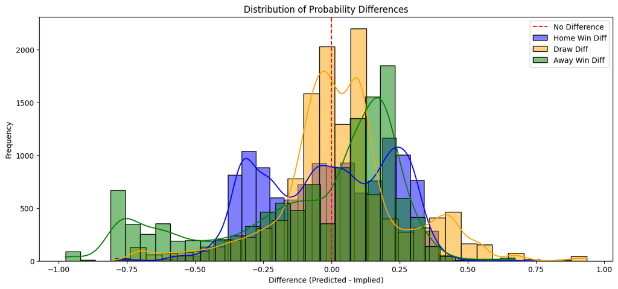

[output not shown]

```python
import matplotlib.pyplot as plt
import seaborn as sns

comparison['Home Win Diff'] = comparison['Predicted Home Win Prob'] - comparison['Implied Home Win Prob']
comparison['Draw Diff'] = comparison['Predicted Draw Prob'] - comparison['Implied Draw Prob']
comparison['Away Win Diff'] = comparison['Predicted Away Win Prob'] - comparison['Implied Away Win Prob']

largest_positive_diff = comparison.nlargest(10, 'Home Win Diff')
largest_negative_diff = comparison.nsmallest(10, 'Home Win Diff')
largest_positive_draw = comparison.nlargest(10, 'Draw Diff')
largest_negative_draw = comparison.nsmallest(10, 'Draw Diff')

largest_positive_diff.to_csv('largest_positive_diff_home.csv', index=False)
largest_negative_diff.to_csv('largest_negative_diff_home.csv', index=False)
largest_positive_draw.to_csv('largest_positive_diff_draw.csv', index=False)
largest_negative_draw.to_csv('largest_negative_diff_draw.csv', index=False)

plt.figure(figsize=(14, 6))
sns.histplot(comparison['Home Win Diff'], kde=True, bins=30, color='blue', label='Home Win Diff')
sns.histplot(comparison['Draw Diff'], kde=True, bins=30, color='orange', label='Draw Diff')
sns.histplot(comparison['Away Win Diff'], kde=True, bins=30, color='green', label='Away Win Diff')
plt.axvline(0, color='red', linestyle='--', label='No Difference')
plt.title('Distribution of Probability Differences')
plt.xlabel('Difference (Predicted - Implied)')
plt.ylabel('Frequency')
plt.legend()
plt.show()
comparison['Prediction Match'] = (
    (comparison['Predicted Home Win Prob'] > 0.5) & (comparison['Implied Home Win Prob'] > 0.5) |
    (comparison['Predicted Draw Prob'] > 0.5) & (comparison['Implied Draw Prob'] > 0.5) |
    (comparison['Predicted Away Win Prob'] > 0.5) & (comparison['Implied Away Win Prob'] > 0.5)
)
comparison['P_diff_bin'] = pd.cut(comparison['P_diff'], bins=10)
mismatch_analysis = comparison.groupby('P_diff_bin')['Prediction Match'].mean()

plt.figure(figsize=(14, 6))
mismatch_analysis.plot(kind='bar', color='purple')
plt.title('Mismatch Rates by P_diff Bins')
plt.xlabel('P_diff Bin')
plt.ylabel('Proportion of Correct Predictions')
plt.xticks(rotation=45)
plt.show()

significant_differences = comparison[
    (comparison['Home Win Diff'].abs() > 0.2) |
    (comparison['Draw Diff'].abs() > 0.2) |
    (comparison['Away Win Diff'].abs() > 0.2)
]

significant_differences.to_csv('significant_differences.csv', index=False)

# Explanation:
# - The `nlargest` and `nsmallest` functions identify matches with the highest and lowest differences.
# - `sns.histplot` visualizes distributions of probability differences for Home Win, Draw, and Away Win.
# - Mismatch analysis groups 'P_diff' into bins and computes the mismatch rate for each bin.
# - Rows with significant probability differences (e.g., > 0.2) are saved for further investigation.
```

REFERENCE

In the preparation of this report, I got help from chatGPT regarding the syntax of the python language and understanding of the outputs.